# LA_matplot1

This notebook will be used to show the exploratory analysis that was done and what information was derived from that analysis

[Visit LA Crime Dataset](https://data.lacity.org/A-Safe-City/Crime-Data-from-2010-to-Present/y8tr-7khq)

```python
import pandas as pd
import numpy as np
import matplotlib.pyplot as plt
%matplotlib inline
```

In Input below we are accessing the LA dataset and are using the input to output the first 5 records.

```python
df = pd.read_csv("la_clean.csv")
```

```python
df.head(5)
```

|  | LA_Key | Date_Occurred | Date Reported | Area ID | Area Name | Crime Code | Crime Code Description | Victim Age | Victim Sex | Victim Descent | Premise Code | Premise Description | Status Description | Location |
| --- | --- | --- | --- | --- | --- | --- | --- | --- | --- | --- | --- | --- | --- | --- |
| 0 | 1 | 2010-01-01 00:01:00 | 08/21/2014 | 9 | Van Nuys | 354 | THEFT OF IDENTITY | 82 | F | W | 501.0 | SINGLE FAMILY DWELLING | Invest Cont | (34.186, -118.4159) |
| 1 | 2 | 2010-01-01 00:01:00 | 02/29/2012 | 18 | Southeast | 354 | THEFT OF IDENTITY | 39 | M | H | 501.0 | SINGLE FAMILY DWELLING | Invest Cont | (33.931, -118.2739) |
| 2 | 3 | 2010-01-01 00:01:00 | 02/17/2012 | 18 | Southeast | 812 | CRM AGNST CHLD (13 OR UNDER) (14-15 & SUSP 10 ... | 11 | F | B | 501.0 | SINGLE FAMILY DWELLING | Invest Cont | (33.9402, -118.2717) |
| 3 | 4 | 2010-01-01 00:01:00 | 12/22/2011 | 21 | Topanga | 354 | THEFT OF IDENTITY | 62 | M | W | 502.0 | MULTI-UNIT DWELLING (APARTMENT, DUPLEX, ETC) | Invest Cont | (34.2198, -118.594) |
| 4 | 5 | 2010-01-01 00:01:00 | 01/04/2012 | 18 | Southeast | 354 | THEFT OF IDENTITY | 35 | F | B | 501.0 | SINGLE FAMILY DWELLING | Invest Cont | (33.958, -118.2893) |

InInput below, a chart is made that shows the number of crimes that occur at each day of the week. From the chart it can be seen that the number of crimes occurring each day are very close to close each other especially Thursday-Monday. The day when crimes occur the most is Friday and when the day when crimes occurs least is Sunday. From this analysis it can be surmasized that crimes are more likely to occur when people are not attending school/work and least likely to occur when people are preparing to go back to work/school.

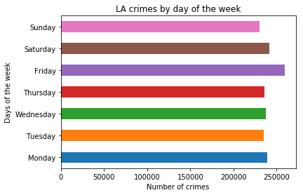

```python
df.index = pd.DatetimeIndex(df['Date_Occurred'])
days = ['Monday','Tuesday','Wednesday','Thursday','Friday','Saturday','Sunday']
df.groupby([df.index.dayofweek]).size().plot(kind='barh')
plt.ylabel('Days of the week')
plt.yticks(np.arange(7), days)
plt.xlabel('Number of crimes')
plt.title('LA crimes by day of the week')
plt.show()
```

InInput below, a chart is made that shows the number of crimes that occur at each month of year. From the chart it can be seen that the number of crimes occurring each day are very close to close each other. The months when crimes occur the most is January and March and when the day when crimes occurs least is November. From this analysis it can be surmasized that crimes are more likely to occur when people are no longer visiting families and celebrating the holidays and least likely to occur when people are preparing for the holidays.

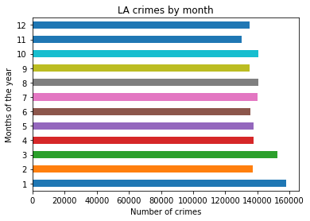

```python
df.groupby([df.index.month]).size().plot(kind='barh')
plt.xlabel('Number of crimes')
plt.ylabel('Months of the year')
plt.title('LA crimes by month')
plt.show()
```

In Input below There are charts made for each crime to see how each crime is moving throughout time.

### Crime Chart Analysis

**Rising Crime**

Arson

Assault with Deadly Weapon/Aggravated Assault

Attempted Robbery

Battery/Simple Assault

Battery Police - Simple

Battery With Sexual Contact

Bike Stolen

Brandish Weapon

Bunco/Grand Theft

Bunco/Petty Theft

Burglary From Vehicle

Violation Of Restraining Order

Trespassing

Vandelism - Felony

Theft - Person

Theft From Motor Vehicle - Grand

Theft From Motor Vehicle - Petty

Shoplifting/Petty Theft

Shoplifting - Grand Theft

Robbery

Other Assault

Indecent Exposure

Intimate Partner - Aggravated Assault

Intimate Partner - Simple Assault

**Declining Crime**

Child Annoying (17 and Under)

Child Neglect

Violation Of Court Order

Vandalism - Misdemeanor

Vehicle - Attempt Stolen

Threathening Calls/Letters

Theft Plain - Petty

Theft - Grand

Theft Of Identity

Sex - Unlawful

Letters - Lewd

Other Miscellaneous Crime

Criminal Threats - No Weapon displayed

Crime Against Child

**Steady/Rise AND Decline Crime**

Burglary

Burglary From Vehicle - Attempted

Burglary - Attempt

Child Abuse(Physical) - Simple Assault

Contempt Of Court

Vehicle - Stolen

Rape - Forcible

Resisting Arrest

Disturbing The Peace

Document Forgery/Stolen Felony

Embezzlement/Grand Theft

Discharge Firearms/Shots Fired

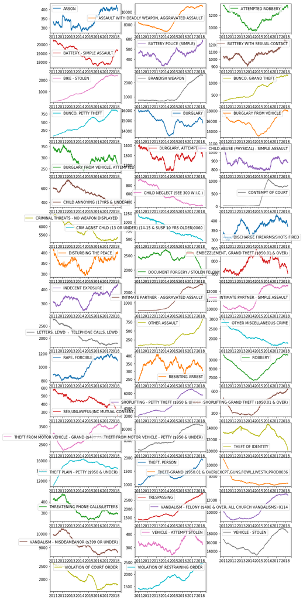

```python
la_crimes = df.pivot_table('LA_Key', aggfunc=np.size, columns='Crime Code Description', index=df.index.date, fill_value=0)
la_crimes.index = pd.DatetimeIndex(la_crimes.index)
plot = la_crimes.rolling(365).sum().plot(figsize=(12, 30), subplots=True, layout=(-1, 3), sharex=False, sharey=False)
```

input below shows that the number of crimes has dropped from 2014 and then from there it started rising until 2017where it has continued to drop

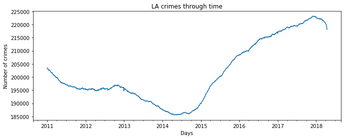

```python
plt.figure(figsize=(11,4))
df.resample('D').size().rolling(365).sum().plot()
plt.title('LA crimes through time')
plt.ylabel('Number of crimes')
plt.xlabel('Days')
plt.show()
```

Input below shows that there has been a peridoic pattern from 2010 from mid 2017. In 2018, the number of crimes dropped considerably.

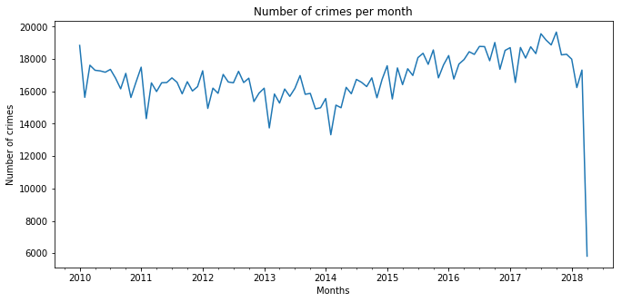

```python
plt.figure(figsize=(11,5))
df.resample('M').size().plot(legend=False)
plt.title('Number of crimes per month')
plt.xlabel('Months')
plt.ylabel('Number of crimes')
plt.show()
```

Input below shows that battery - simple Assault has the highest crime rate while Burglary From Vehicle - Attempted and Other Assault have lowest crime rate.

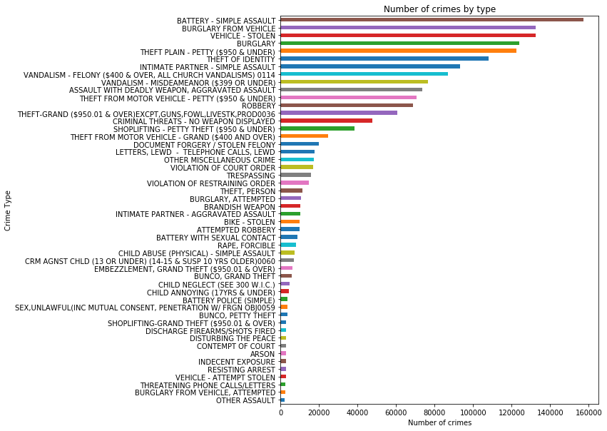

```python
plt.figure(figsize=(8,10))
df.groupby([df['Crime Code Description']]).size().sort_values(ascending=True).plot(kind='barh')
plt.title('Number of crimes by type')
plt.ylabel('Crime Type')
plt.xlabel('Number of crimes')
plt.show()
```

Input below shows that the Location with the most crime is Street and Single Family Dwelling and the Location with the lowest crime is in public locations and government locations

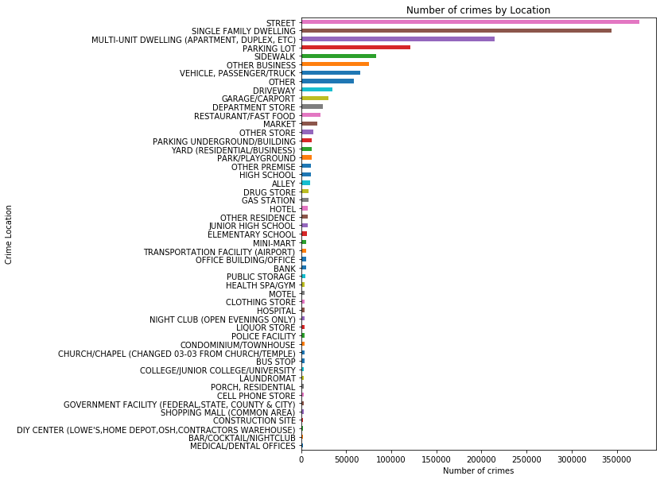

```python
plt.figure(figsize=(8,10))
df.groupby([df['Premise Description']]).size().sort_values(ascending=True).plot(kind='barh')
plt.title('Number of crimes by Location')
plt.ylabel('Crime Location')
plt.xlabel('Number of crimes')
plt.show()
```

Input below shows that 77th Street has the highest crime rate while Hollenbeck has lowest crime rate.

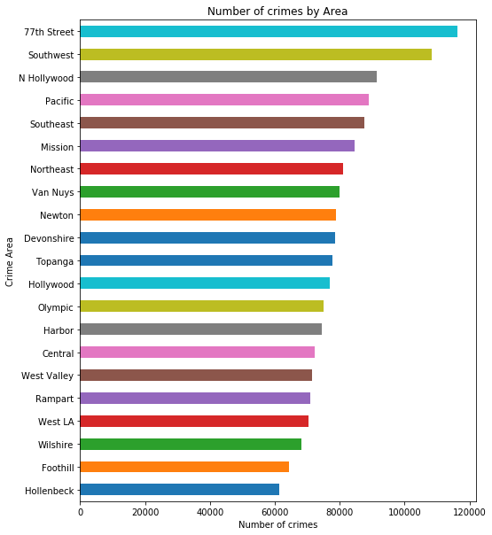

```python
plt.figure(figsize=(8,10))
df.groupby([df['Area Name']]).size().sort_values(ascending=True).plot(kind='barh')
plt.title('Number of crimes by Area')
plt.ylabel('Crime Area')
plt.xlabel('Number of crimes')
plt.show()
```

Input below shows that wrapper functions were made to make some minimal preprocessing and make the heatmap visualization. Heatmaps were made nicer to look by using a clustering algorithm to sort the rows into meaningful groups and use group labels to re-sort our matrix.

```python
from sklearn.cluster import AgglomerativeClustering as AC

def scale_df(df,axis=0):
    '''
    A utility function to scale numerical values (z-scale) to have a mean of zero
    and a unit variance.
    '''
    return (df - df.mean(axis=axis)) / df.std(axis=axis)

def plot_hmap(df, ix=None, cmap='bwr'):
    '''
    A function to plot heatmaps that show temporal patterns
    '''
    if ix is None:
        ix = np.arange(df.shape[0])
    plt.imshow(df.iloc[ix,:], cmap=cmap)
    plt.colorbar(fraction=0.03)
    plt.yticks(np.arange(df.shape[0]), df.index[ix])
    plt.xticks(np.arange(df.shape[1]))
    plt.grid(False)
    plt.show()

def scale_and_plot(df, ix = None):
    '''
    A wrapper function to calculate the scaled values within each row of df and plot_hmap
    '''
    df_marginal_scaled = scale_df(df.T).T
    if ix is None:
        ix = AC(4).fit(df_marginal_scaled).labels_.argsort() # a trick to make better heatmaps
    cap = np.min([np.max(df_marginal_scaled.as_matrix()), np.abs(np.min(df_marginal_scaled.as_matrix()))])
    df_marginal_scaled = np.clip(df_marginal_scaled, -1*cap, cap)
    plot_hmap(df_marginal_scaled, ix=ix)

def normalize(df):
    result = df.copy()
    for feature_name in df.columns:
        max_value = df[feature_name].max()
        min_value = df[feature_name].min()
        result[feature_name] = (df[feature_name] - min_value) / (max_value - min_value)
    return result
```

Input below shows what the frequency of each crime to occur at a particular hour.

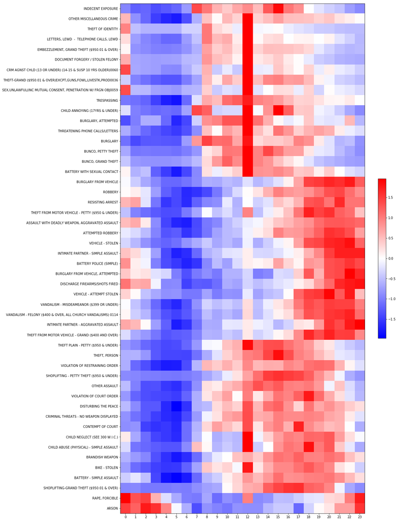

```python
hour_by_type     = df.pivot_table(values='LA_Key', index='Crime Code Description',
                        columns=df.index.hour, aggfunc=np.size).fillna(0)
plt.figure(figsize=(15,35))
scale_and_plot(hour_by_type)
```

Input below shows what the frequency of crime to occur at a particular hour at a particular location.

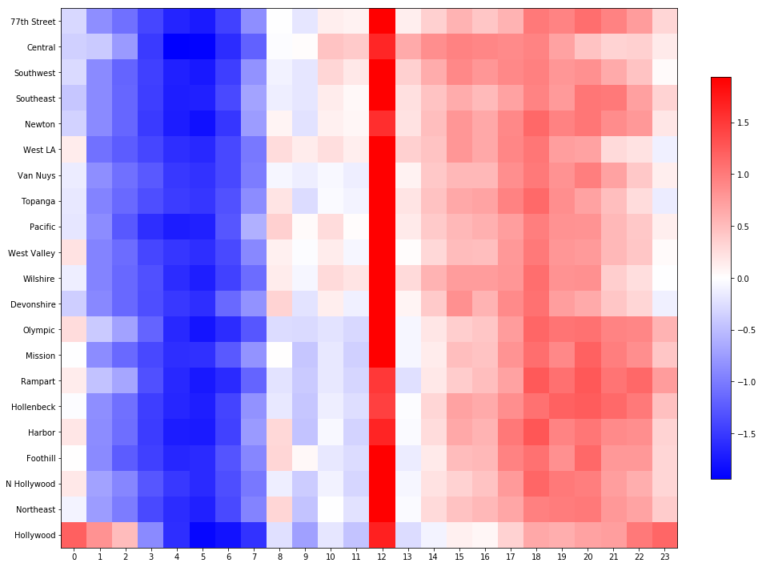

```python
hour_by_location = df.pivot_table(values='LA_Key', index='Area Name', columns=df.index.hour, aggfunc=np.size).fillna(0)
plt.figure(figsize=(15,15))
scale_and_plot(hour_by_location)
```

Input below shows what the frequency of crime to occur at a particular Day.

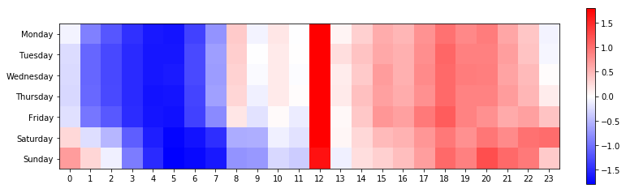

```python
hour_by_week = df.pivot_table(values='LA_Key', index=df.index.hour,
                        columns=df.index.weekday_name, aggfunc=np.size).fillna(0)
hour_by_week = hour_by_week[days].T
plt.figure(figsize=(12,4))
scale_and_plot(hour_by_week, ix=np.arange(7))
```

Input below shows what the frequency of each crime to occur at a particular day of the week.

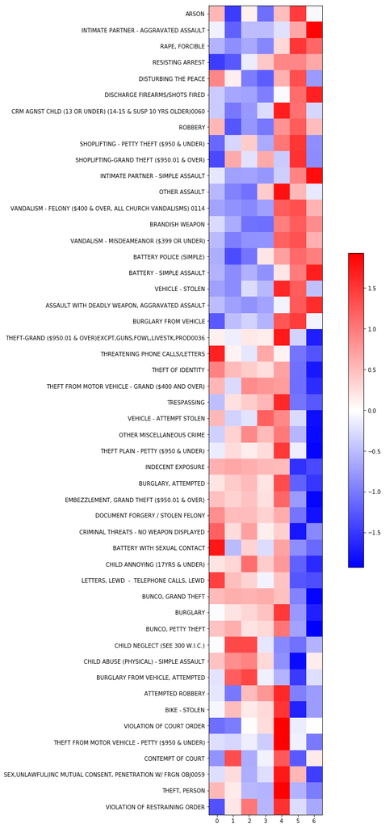

```python
dayofweek_by_type = df.pivot_table(values='LA_Key', index='Crime Code Description', columns=df.index.dayofweek,
                                   aggfunc=np.size).fillna(0)
plt.figure(figsize=(17,27))
scale_and_plot(dayofweek_by_type)
```

Input below shows what the frequency of crime to occur at each location on each day of the week.

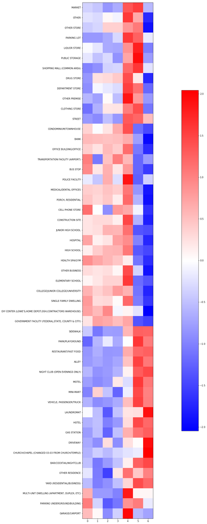

```python
dayofweek_by_location = df.pivot_table(values='LA_Key', index='Premise Description',
                                           columns=df.index.dayofweek, aggfunc=np.size).fillna(0)
plt.figure(figsize=(45,42))
scale_and_plot(dayofweek_by_location)
```

Input below shows what what is the most likely location for each crime to occur at.

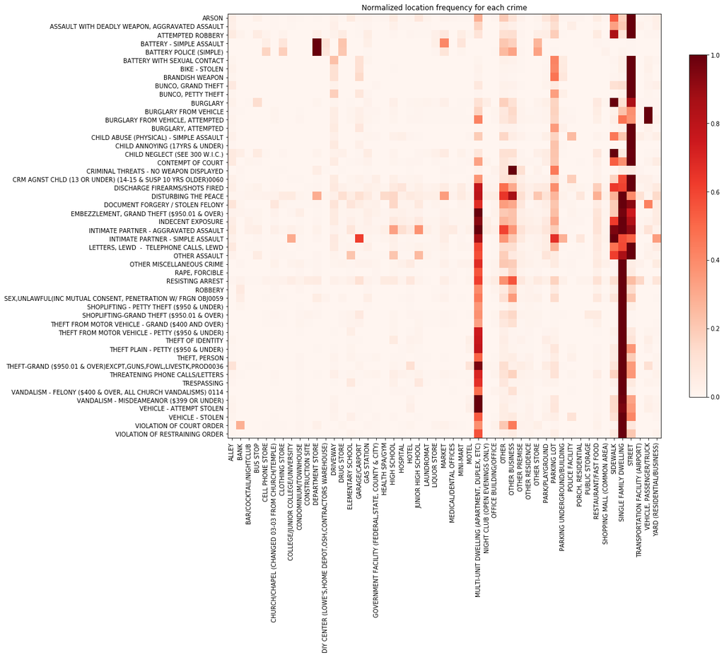

```python
location_by_type  = df.pivot_table(values='LA_Key', index='Premise Description',
                                       columns='Crime Code Description', aggfunc=np.size).fillna(0)

df = normalize(location_by_type)
ix = AC(3).fit(df.T).labels_.argsort() # a trick to make better heatmaps
plt.figure(figsize=(17,13))
plt.imshow(df.T.iloc[ix,:], cmap='Reds')
plt.colorbar(fraction=0.03)
plt.xticks(np.arange(df.shape[0]), df.index, rotation='vertical')
plt.yticks(np.arange(df.shape[1]), df.columns)
plt.title('Normalized location frequency for each crime')
plt.grid(False)
plt.show()
```